# Checks on the Bayesian Hierarchical Models

Kristian Brock

10 September, 2019

```r
# This script in the root of the project loads the datasets
source('../../../Load.R')

library(brms)
library(ggplot2)
```

## DLT Model

```r
dlt_mod <- readRDS('dlt_mod.rds')
```

```r
dlt_mod
```

```
 Family: binomial
  Links: mu = logit
Formula: Events | trials(n) ~ (1 + DoseLevel | AnalysisSeriesId) + (1 + DoseLevel | DoseVaryingTreatmentType)
   Data: dlt %>% left_join(studies, by = "Study") (Number of observations: 643)
Samples: 4 chains, each with iter = 3000; warmup = 1500; thin = 1;
         total post-warmup samples = 6000

Group-Level Effects:
~AnalysisSeriesId (Number of levels: 155)
                         Estimate Est.Error l-95% CI u-95% CI Eff.Sample Rhat
sd(Intercept)                0.88      0.11     0.67     1.11       2122 1.00
sd(DoseLevel)                0.45      0.10     0.26     0.64       1516 1.00
cor(Intercept,DoseLevel)     0.48      0.23     0.01     0.89       1276 1.00

~DoseVaryingTreatmentType (Number of levels: 16)
                         Estimate Est.Error l-95% CI u-95% CI Eff.Sample Rhat
sd(Intercept)                0.66      0.33     0.14     1.47       1816 1.00
sd(DoseLevel)                0.87      0.27     0.46     1.52       1613 1.00
cor(Intercept,DoseLevel)     0.15      0.55    -0.85     0.97        412 1.02

Population-Level Effects:
          Estimate Est.Error l-95% CI u-95% CI Eff.Sample Rhat
Intercept    -2.54      0.38    -3.36    -1.82        644 1.01

Samples were drawn using sampling(NUTS). For each parameter, Eff.Sample
is a crude measure of effective sample size, and Rhat is the potential
scale reduction factor on split chains (at convergence, Rhat = 1).
```

Rhats and Eff.Samples look fine. No divergent transitions or violations of max tree-depth are reported.

```
Using 10 posterior samples for ppc type 'dens_overlay' by default.
```

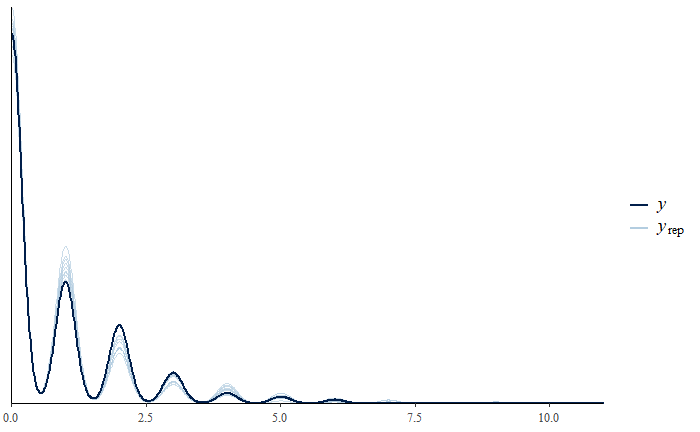

```r
pp_check(dlt_mod)
```

The x-axis is the sampled number of DLTs, conditional on the number of attempts, using all of the DLT series. Posterior samples are a faithful representation of the observed data.

Distribution of series-level intercepts:

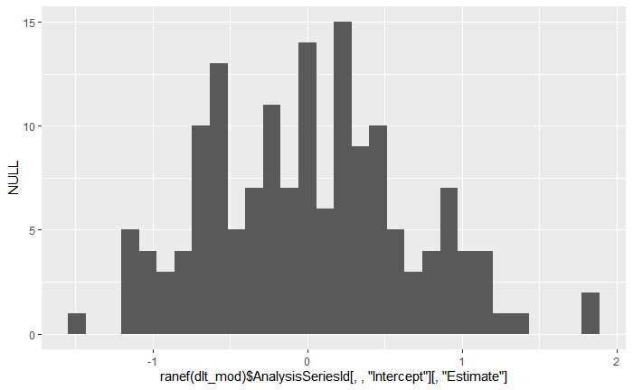

```r
qplot(ranef(dlt_mod)$AnalysisSeriesId[, , 'Intercept'][,'Estimate'],
      geom = 'histogram')
```

Normal enough.

Distribution of series-level gradients for DoseLevel:

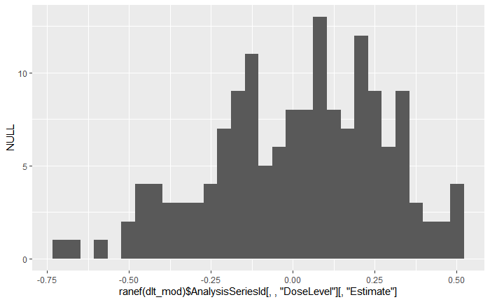

```r
qplot(ranef(dlt_mod)$AnalysisSeriesId[, , 'DoseLevel'][,'Estimate'],
      geom = 'histogram')
```

Bit of a negative skew but not alarmingly non-normal.

Distribution of series-level intercepts:

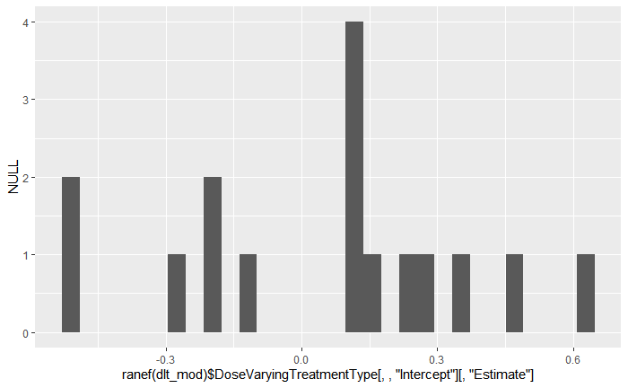

```r
qplot(ranef(dlt_mod)$DoseVaryingTreatmentType[, , 'Intercept'][,'Estimate'],
      geom = 'histogram')
```

There are not many of these. There appears to be some central tendency and symmetry. Normal is not a poor working model.

Distribution of series-level gradients for DoseLevel:

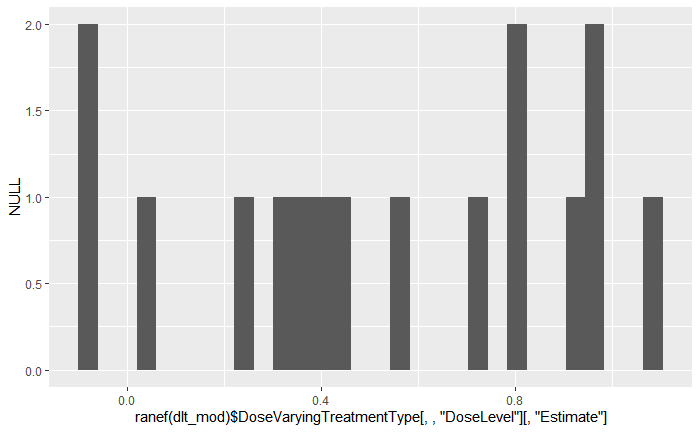

```r
qplot(ranef(dlt_mod)$DoseVaryingTreatmentType[, , 'DoseLevel'][,'Estimate'],
      geom = 'histogram')
```

Now these do look kinda weird. Again, small numbers here.

## Objective Response Model

```r
obj_resp_mod <- readRDS('obj_resp_mod.rds')
```

```r
obj_resp_mod
```

```
 Family: binomial
  Links: mu = logit
Formula: Events | trials(n) ~ (1 + DoseLevel | AnalysisSeriesId) + (1 + DoseLevel | DoseVaryingTreatmentType)
   Data: obj_resp %>% left_join(studies, by = "Study") %>%  (Number of observations: 372)
Samples: 4 chains, each with iter = 3000; warmup = 1500; thin = 1;
         total post-warmup samples = 6000

Group-Level Effects:
~AnalysisSeriesId (Number of levels: 93)
                         Estimate Est.Error l-95% CI u-95% CI Eff.Sample Rhat
sd(Intercept)                2.58      0.31     2.04     3.26       1648 1.00
sd(DoseLevel)                0.19      0.12     0.01     0.43       1449 1.00
cor(Intercept,DoseLevel)     0.16      0.48    -0.86     0.93       3978 1.00

~DoseVaryingTreatmentType (Number of levels: 12)
                         Estimate Est.Error l-95% CI u-95% CI Eff.Sample Rhat
sd(Intercept)                1.35      0.89     0.13     3.56        887 1.00
sd(DoseLevel)                0.25      0.19     0.01     0.71       1704 1.00
cor(Intercept,DoseLevel)     0.15      0.57    -0.92     0.96       2210 1.00

Population-Level Effects:
          Estimate Est.Error l-95% CI u-95% CI Eff.Sample Rhat
Intercept    -2.68      0.67    -4.26    -1.49       1865 1.00

Samples were drawn using sampling(NUTS). For each parameter, Eff.Sample
is a crude measure of effective sample size, and Rhat is the potential
scale reduction factor on split chains (at convergence, Rhat = 1).
```

Rhats and Eff.Samples look fine. No divergent transitions or violations of max tree-depth are reported.

```
Using 10 posterior samples for ppc type 'dens_overlay' by default.
```

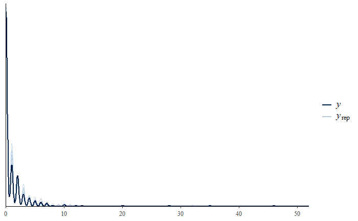

```r
pp_check(obj_resp_mod)
```

The x-axis is the sampled number of responses, conditional on the number of attempts, using all of the response series. Posterior samples are a faithful representation of the observed data.

Distribution of series-level intercepts:

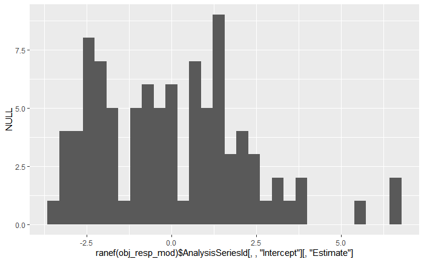

```r
qplot(ranef(obj_resp_mod)$AnalysisSeriesId[, , 'Intercept'][,'Estimate'],
      geom = 'histogram')
```

Distribution of series-level gradients for DoseLevel:

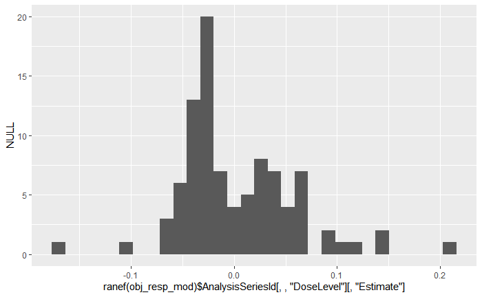

```r
qplot(ranef(obj_resp_mod)$AnalysisSeriesId[, , 'DoseLevel'][,'Estimate'],
      geom = 'histogram')
```

Long tails but not alarmingly non-normal.

Distribution of series-level intercepts:

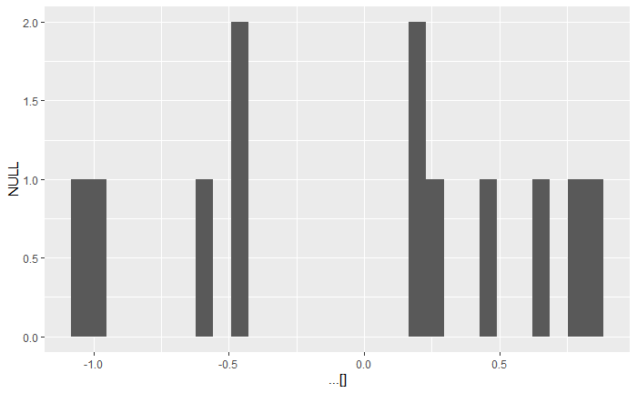

```r
qplot(ranef(obj_resp_mod)$DoseVaryingTreatmentType[, , 'Intercept'][,'Estimate'],
      geom = 'histogram')
```

Distribution of series-level gradients for DoseLevel:

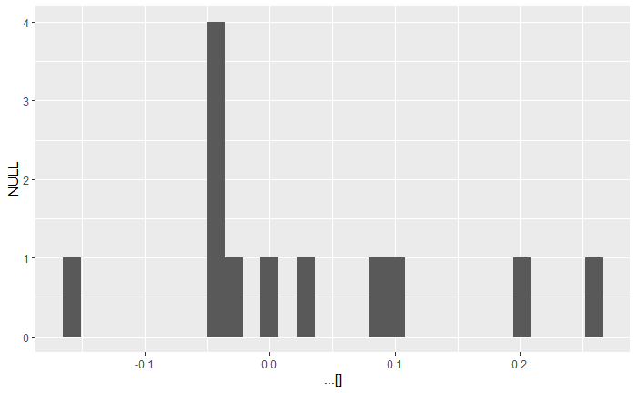

```r
qplot(ranef(obj_resp_mod)$DoseVaryingTreatmentType[, , 'DoseLevel'][,'Estimate'],
      geom = 'histogram')
```

Again, small numbers here but apparent long tails.